# R语言练习

huzhibin

2021/9/6

### 逻辑运算

### a | b 或运算

```r
a = rep(1:3,5)
b = (a==1|a==3)
b
```

```
##  [1]  TRUE FALSE  TRUE  TRUE FALSE  TRUE  TRUE FALSE  TRUE  TRUE FALSE  TRUE
## [13]  TRUE FALSE  TRUE
```

```r
sum(b)
```

```
## [1] 10
```

### a & b 与运算

```r
a = rep(1:3,5)
b = (a>1&a<3)
b
```

```
##  [1] FALSE  TRUE FALSE FALSE  TRUE FALSE FALSE  TRUE FALSE FALSE  TRUE FALSE
## [13] FALSE  TRUE FALSE
```

```r
sum(b)
```

```
## [1] 5
```

### 创建向量

### x = c(a, b, c, d, e, f )

创建包含指定元素的行向量； c() 为数据元素的连接函数；

```r
x = c(1,2,3,4,5);x
```

```
## [1] 1 2 3 4 5
```

### x = first : last

创建从 first 开始，间隔为 1， 到 last 结束的向量；

```r
x=1:9;x
```

```
## [1] 1 2 3 4 5 6 7 8 9
```

### x = rep ( a，time = k）

将对象 a 重复 k 次，赋值给x；

```r
x = rep (1:3,time=3);x
```

```
## [1] 1 2 3 1 2 3 1 2 3
```

### x = rep ( a，each = k）

将对象 a 的每个元素重复 k 次， 然后将结果赋值给对象 x；

```r
x = rep(1:3,each=3);x
```

```
## [1] 1 1 1 2 2 2 3 3 3
```

缺省参数名时第二个参数默认为time

```r
x = rep(1:3,3);x
```

```
## [1] 1 2 3 1 2 3 1 2 3
```

### 赋值

```r
X=0
```

### 循环语句

```r
for(k in 1:10)
   {X[k]=k^2+1; print(X);}
```

```
## [1] 2
## [1] 2 5
## [1]  2  5 10
## [1]  2  5 10 17
## [1]  2  5 10 17 26
## [1]  2  5 10 17 26 37
## [1]  2  5 10 17 26 37 50
## [1]  2  5 10 17 26 37 50 65
## [1]  2  5 10 17 26 37 50 65 82
##  [1]   2   5  10  17  26  37  50  65  82 101
```

```r
X=0
```

中间没有的数会补上NA

```r
for(k in c(1,2,3,5)){X[k]=k^2+1; print(X);}
```

```
## [1] 2
## [1] 2 5
## [1]  2  5 10
## [1]  2  5 10 NA 26
```

### rbinom(n, size, prob)

生成n个符合B~(size,prob)的数，二项分布，size是试验次数，prob是成功的概率

```r
x=rbinom(10,10,0.3);
print(x);
```

```
##  [1] 2 3 3 3 3 3 2 0 5 2
```

```r
print(sum(x))
```

```
## [1] 26
```

### dbinom(n,size,prob)

给出n点的概率密度

### cbind(a,b)

以列的方式链接(column)

```r
x=0:10;
y=dbinom(x,10,0.5);
print(cbind(x,y))
```

```
##        x            y
##  [1,]  0 0.0009765625
##  [2,]  1 0.0097656250
##  [3,]  2 0.0439453125
##  [4,]  3 0.1171875000
##  [5,]  4 0.2050781250
##  [6,]  5 0.2460937500
##  [7,]  6 0.2050781250
##  [8,]  7 0.1171875000
##  [9,]  8 0.0439453125
## [10,]  9 0.0097656250
## [11,] 10 0.0009765625
```

### x = runif (k, a, b)

生成 k 个以(a, b) 为参数的服从均匀分布的随机数。

```r
x = runif (10, 1, 5);x
```

```
##  [1] 2.593665 2.344600 2.390736 1.981948 1.824579 2.001837 2.095099 4.372742
##  [9] 4.120087 3.668367
```

### rnorm(n,a,b)

生成n个正态随机数，均值为a，标准差为b

```r
 x=rnorm(20,1,0.5); print(x)
```

```
##  [1] 0.8534141 1.3894641 0.8515588 1.4698477 1.5345842 1.0744034 0.9823344
##  [8] 0.8281966 1.6346150 0.1007027 0.6993782 1.3617973 0.6203965 1.6531101
## [15] 0.9656026 1.7123205 1.3040033 1.6189686 0.6235828 0.6497125
```

### rexp(n,a)

指数分布随机数，生成n个参数值$\lambda$为a的随机数，表观来看$\lambda$越小，数值越大。
$$f(x) = λ {e}^{- λ x}$$

```r
y = rexp(20,1); print(y)
```

```
##  [1] 0.96200808 0.65121007 1.16456708 0.66149395 0.89307990 1.85072693
##  [7] 1.12535431 0.14769696 0.54686903 0.18832023 0.17978824 0.55636484
## [13] 0.94831259 3.89181628 1.53068501 0.53140216 0.15292037 0.03093022
## [19] 0.93932263 1.06414260
```

### 一个维度的绘图

c(x,y)，把x，y连接在了一起

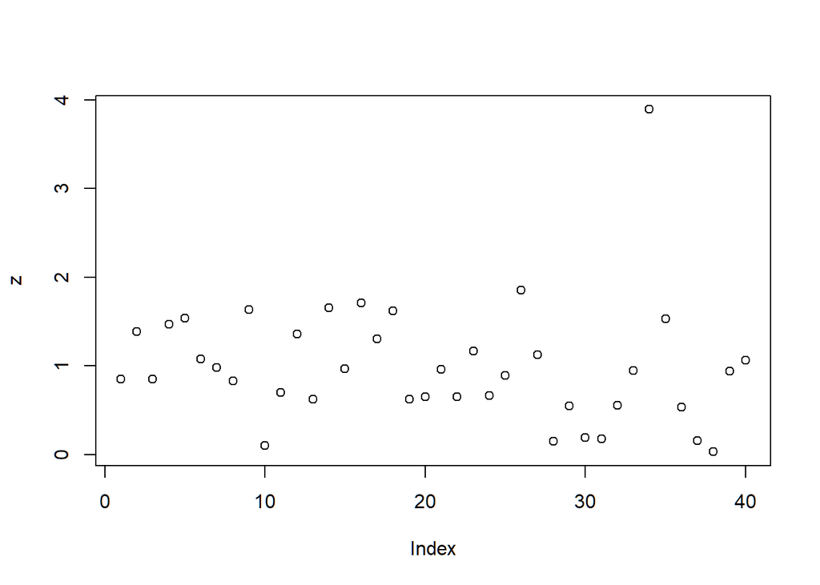

```r
 z = c(x,y);   plot(z)
```

### seq(from=a,to=b,length=n)

从a到b的序列，输出长度为n

### seq(from=a,to=b,by=n)

从a到b的序列，步长为n

```r
seq(1,10,length=5)
```

```
## [1]  1.00  3.25  5.50  7.75 10.00
```

```r
seq(1,10,by=5)
```

```
## [1] 1 6
```

不加by/length默认为by

```r
seq(1,10,5)
```

```
## [1] 1 6
```

```r
Number_Box = 10;
 Bound = seq(from=0,to=1,length=Number_Box);
 SampleX = runif(500);
 Frequence = 0;
 for (k in 1:Number_Box){
     Index=(SampleX>Bound[k])*(SampleX<Bound[k+1]);
     #随机数在而二者中间
     Frequence[k]=sum(Index);}
```

### barplot绘制条形图

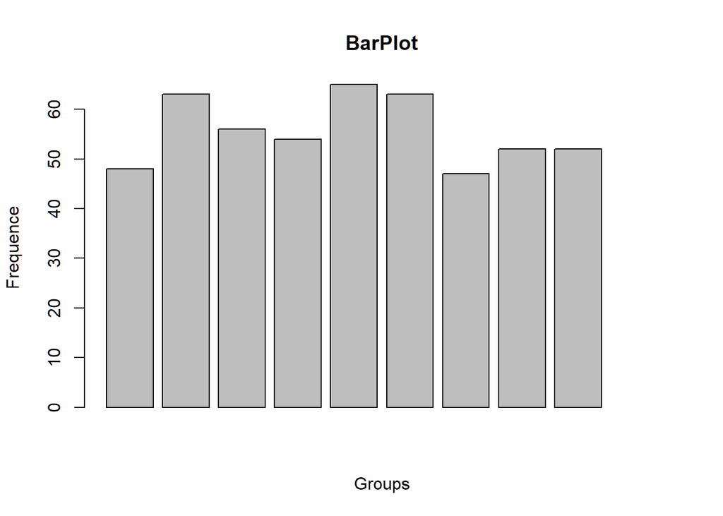

```r
barplot(Frequence,xlab="Groups",ylab="Frequence",main="BarPlot")
```

### hist

hist画条形图，只给一个参数时，默认是频数分布表 hist(vector,breaks=,freq=) breaks值为数字，数字越大条形图分得越细，可缺省 freq=F意为概率密度分布

### density(x)

返回x的密度

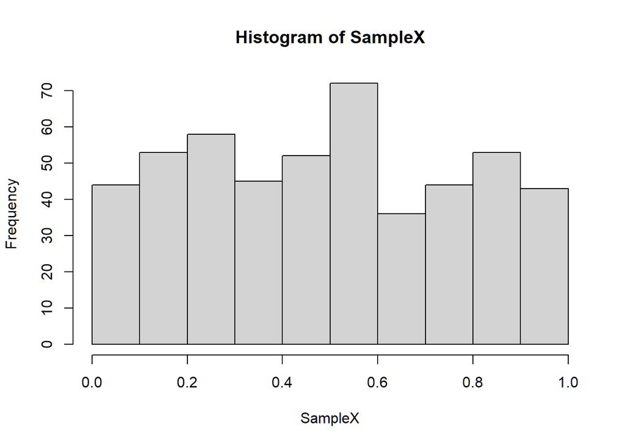

```r
hist(SampleX)
```

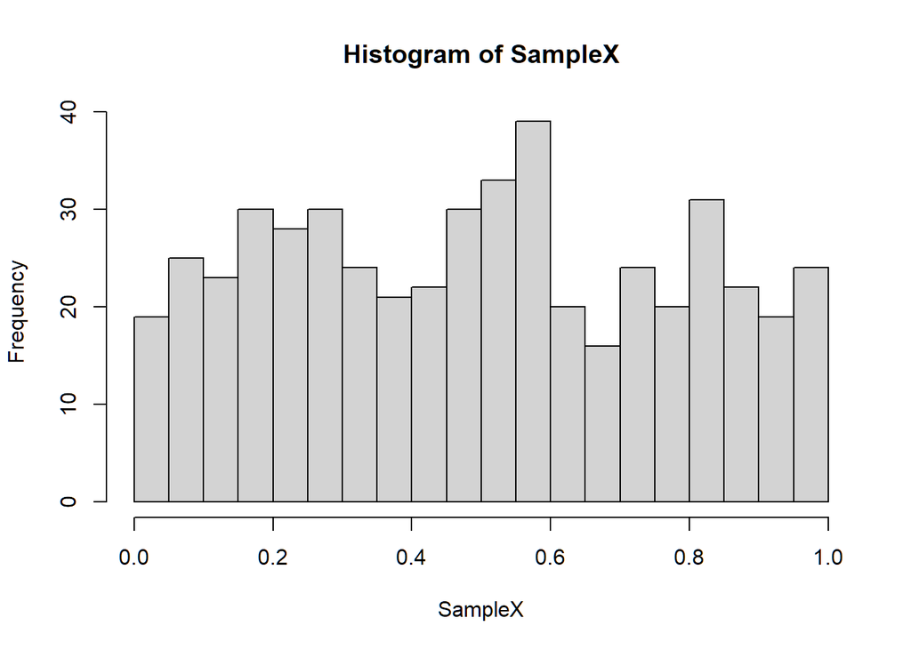

```r
hist(SampleX,20)
```

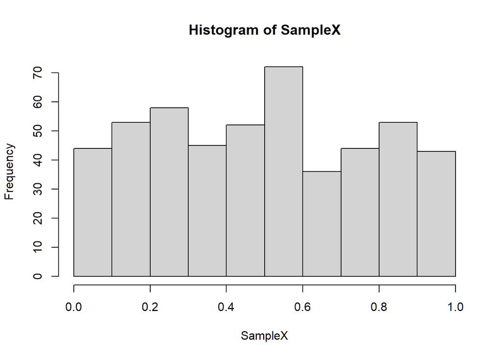

```r
hist(SampleX,10)
```

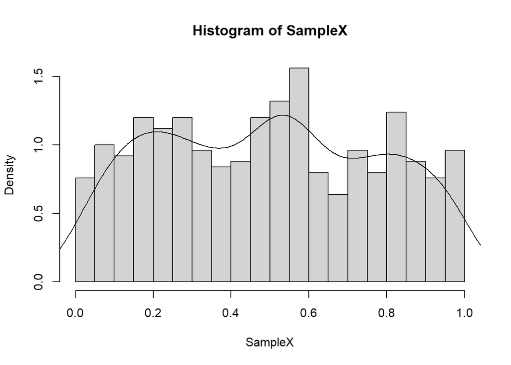

```r
hist(SampleX,20,freq=F)
lines(density((SampleX)))
```

### matplot绘图

按照列绘图，pch是点的类型（小于16的整数或者字符），type是图的类型

- ‘p’：仅仅绘制各个散点；
- ‘l’：各个散点构成的连线；
- ‘s’：各个散点构成的阶梯线；
- ‘b’：直线连接各个散点；
- ‘o’ ：直线连接并覆盖各个散点；
- ‘h’ ：绘制点到坐标轴的垂直线；

### apply

apply函数经常用来计算矩阵中行或列的均值、和值的函数

apply(b,1,sum)

第一个参数是指要参与计算的矩阵；

第二个参数是指按行计算还是按列计算，1——表示按行计算，2——按列计算；

第三个参数是指具体的运算参数。

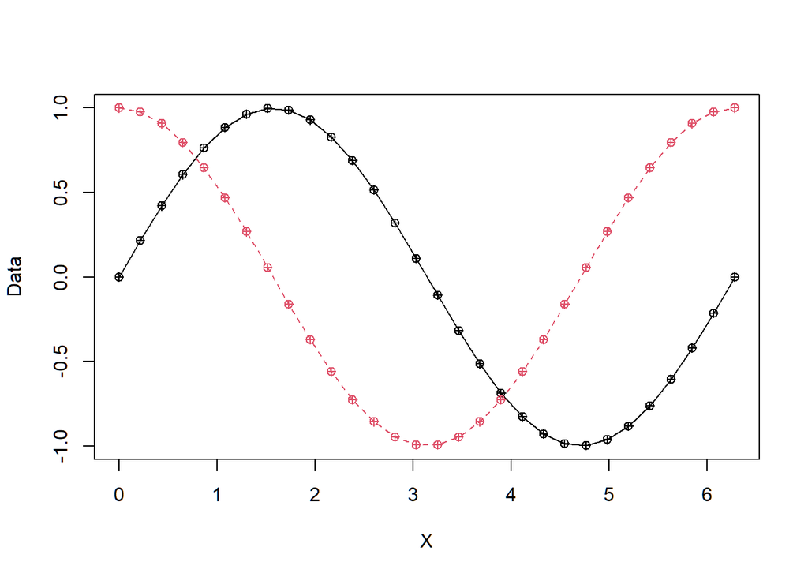

```r
X = seq(0, 2*pi, length = 30);
Y = sin(X);   Z = cos(X);
Data = cbind (Y,Z);
matplot (X, Data, pch = 10, type = 'o');
```

```r
YZ_Min = apply(Data,1,min)
```

### plot画图

### sort排序

decreasing为TRUE，表示降序 decreasing为FALSE，表示升序

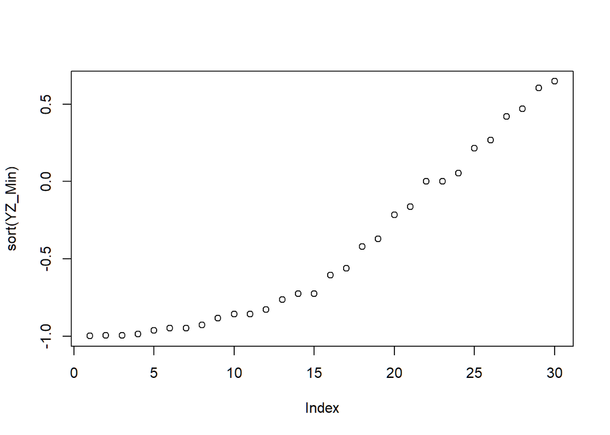

```r
plot(sort(YZ_Min));
```

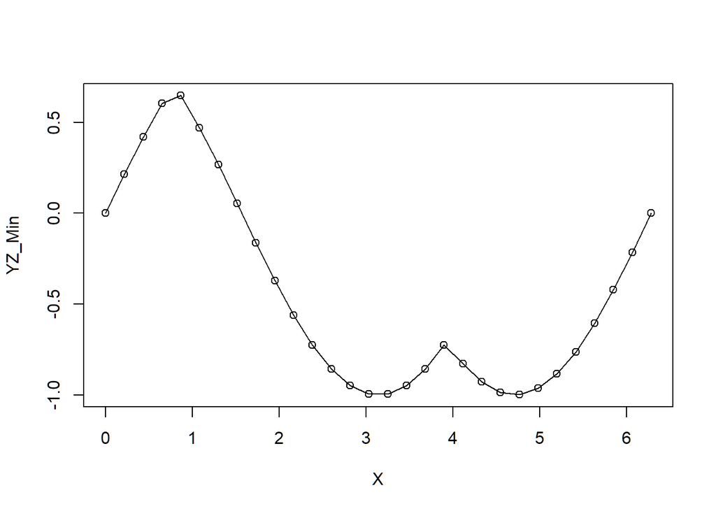

```r
plot(X,YZ_Min);
lines(X,YZ_Min)
```

```r
test=1:9;
sort(test,decreasing = TRUE);
```

```
## [1] 9 8 7 6 5 4 3 2 1
```

### combn(x,m)

组合数，生成矩阵，每一列是一种组合 给出所有组合x：包含用于组合的元素的向量 m：选择元素的数量

```r
Sample = combn(1:5,3);
Sample
```

```
##      [,1] [,2] [,3] [,4] [,5] [,6] [,7] [,8] [,9] [,10]
## [1,]    1    1    1    1    1    1    2    2    2     3
## [2,]    2    2    2    3    3    4    3    3    4     4
## [3,]    3    4    5    4    5    5    4    5    5     5
```

### colSums

按列求和，可以直接求和布尔值

```r
Number_Waster = colSums(Sample <= 2);
Number_Waster
```

```
##  [1] 2 2 2 1 1 1 1 1 1 0
```

```r
Selection = (Number_Waster == 1);
Selection
```

```
##  [1] FALSE FALSE FALSE  TRUE  TRUE  TRUE  TRUE  TRUE  TRUE FALSE
```

```r
Probability = sum(Selection)/choose(5,3);
Probability
```

```
## [1] 0.6
```

### choose

choose(n,k)，给出$C^k_n$的值

```r
choose(5,2)
```

```
## [1] 10
```

### sample抽样

sample(x,size,replace)

replace=T，有放回，默认无放回 ### 省略参数必须位置对应，带参数可以颠倒位置

```r
sample(size=20,replace=T,x=1:9)
```

```
##  [1] 7 9 2 5 7 1 7 2 9 3 3 1 9 3 2 1 9 7 1 7
```

```r
sample(1:9,20,replace=T)
```

```
##  [1] 2 9 3 3 7 6 8 1 6 3 9 1 9 6 1 2 4 4 8 6
```

### matrix生成矩阵

matrix(x,nrow=2,ncol=3)

```r
matrix(1:10,2,5)
```

```
##      [,1] [,2] [,3] [,4] [,5]
## [1,]    1    3    5    7    9
## [2,]    2    4    6    8   10
```

```r
SampleX = 1:5 <= 2;
Number_Repeat = 100;
Sample_Random = sample(SampleX,Number_Repeat*3,replace=TRUE);
SampleY = matrix(Sample_Random,nrow=Number_Repeat,ncol=3);
for(k in 1:Number_Repeat){SampleY[k,] = sample(SampleX,3)};
Number_Waster = rowSums(SampleY);
Selection = (Number_Waster == 1);
Frequency = sum(Selection)/Number_Repeat;
print(Frequency-Probability)
```

```
## [1] -0.02
```

### mean均值

### sd标准差

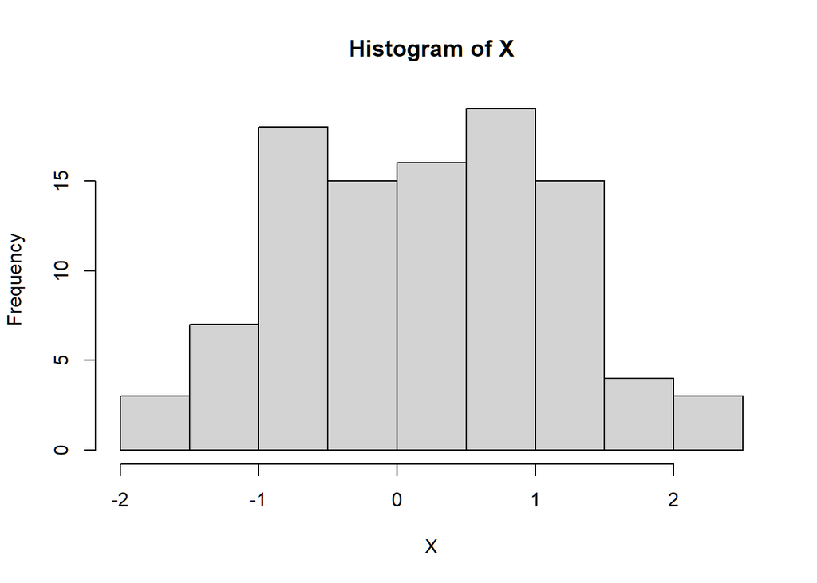

```r
X = rnorm(100,0,1);  hist(X);
```

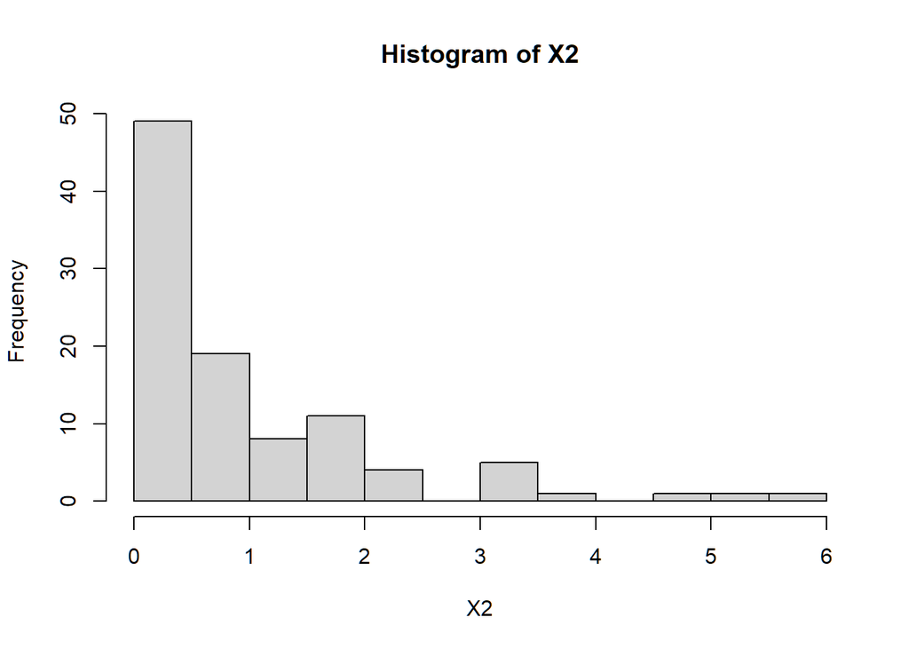

```r
X2 = X^2;  hist(X2);
```

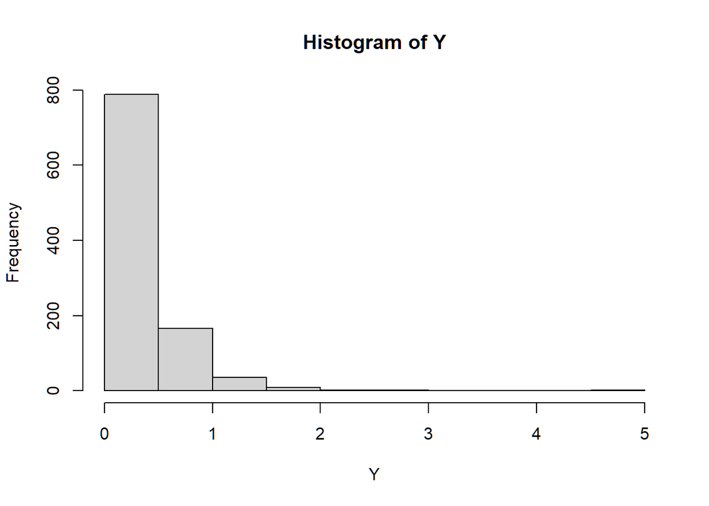

```r
E_X2 = mean(X2); D_X2 = sd(X2);
Y = rexp(1000,3);  hist(Y);
```

```r
E_X2 = mean(X2); D_X2 = sd(X2)
```

### lines连线

hist加入freq=F可以把纵轴变成密度。

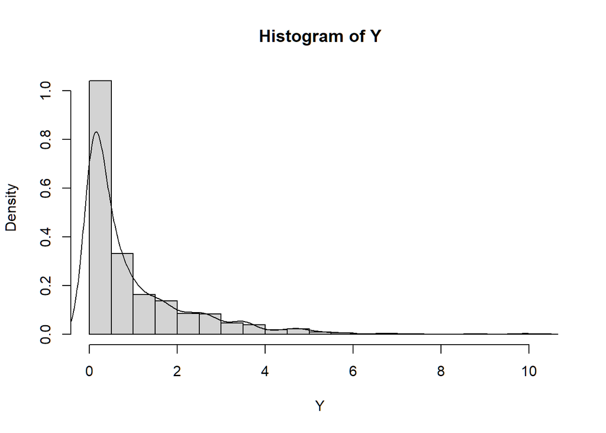

```r
X = rnorm(1000);
Y = X^2;
hist(Y,20,freq = F);
lines(density(Y))
```

### boxplot

boxplot画箱线图

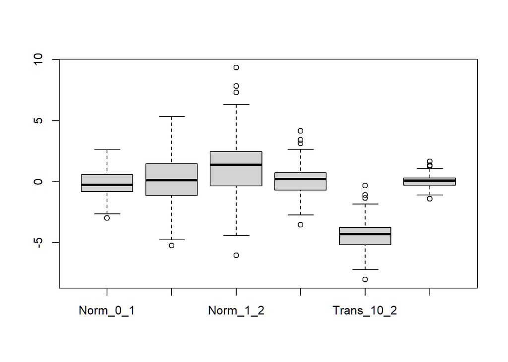

```r
Norm_0_1 = rnorm(200,0,1);
Norm_0_2 = rnorm(200,0,2);
Norm_1_2 = rnorm(200,1,2);
Trans_1_2 = (Norm_1_2-1)/2;
Trans_10_2 = (Norm_1_2-10)/2;
Trans_1_5 = (Norm_1_2-1)/5;
Data= cbind(Norm_0_1,Norm_0_2,Norm_1_2,Trans_1_2,Trans_10_2,Trans_1_5);
boxplot(Data)
```

### 自定义函数

函数名 <- function(参数){

return()}

```r
Statistic_T <- function(a){
    X = a+1;
    return(X)}
Statistic_T(3)
```

```
## [1] 4
```

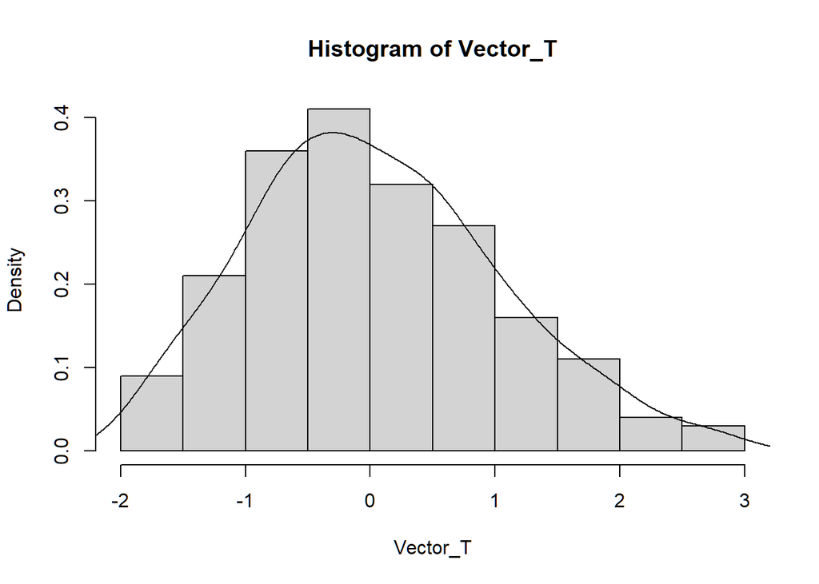

```r
Statistic_T <- function(Number_Sample){
    X = rnorm(Number_Sample);
    S_T = (X-mean(X))/sd(X);
    return(S_T)}
Number_Sample = 100;
Number_Repeat = 200;
Vector_T = as.numeric(vector(length=Number_Repeat))
for (k in 1:Number_Repeat){
    Vector_T[k]= Statistic_T(Number_Sample)};
hist(Vector_T,freq=F);
lines(density(Vector_T))
```

### vector

vector(length=n)生成长度为n的向量，内容全为FALSE

```r
vector(length=20)
```

```
##  [1] FALSE FALSE FALSE FALSE FALSE FALSE FALSE FALSE FALSE FALSE FALSE FALSE
## [13] FALSE FALSE FALSE FALSE FALSE FALSE FALSE FALSE
```

### as.numeric

转化为数字

```r
as.numeric(vector(length=20))
```

```
##  [1] 0 0 0 0 0 0 0 0 0 0 0 0 0 0 0 0 0 0 0 0
```

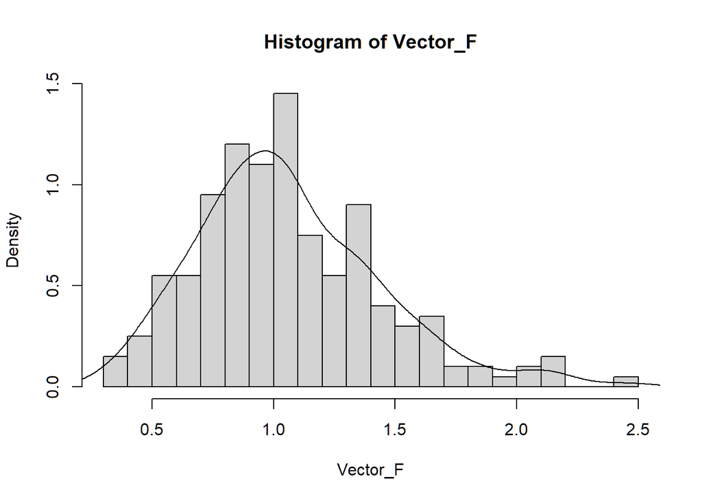

```r
Statistic_F <- function(Number_Sample){
    X1 = rnorm(Number_Sample);
    X2 = rnorm(Number_Sample);
    S_F = sd(X1)/sd(X2);
    return(S_F)}

Number_Sample = 10;
Number_Repeat = 200;
Vector_F = as.numeric(vector(length=Number_Repeat))
for (k in 1:Number_Repeat) {Vector_F[k]= Statistic_F(Number_Sample)};
hist(Vector_F,20,freq=F)
lines(density(Vector_F))
```

### pnorm(x)

返回值是正态分布的分布函数值，比如pnorm（z）等价于P(x≤z)； pnorm(x, mean = a, sd = b, lower.tail = FALSE) 求P(x≤), 那么lower.tail 是TRUE， P(x≥) lower.tail是False

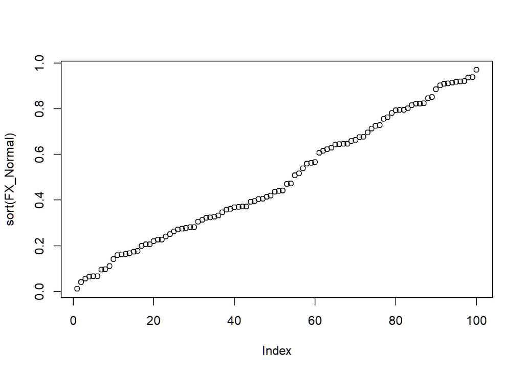

```r
Random_Normal = rnorm(100);
FX_Normal = pnorm(Random_Normal);
plot(sort(FX_Normal))
```

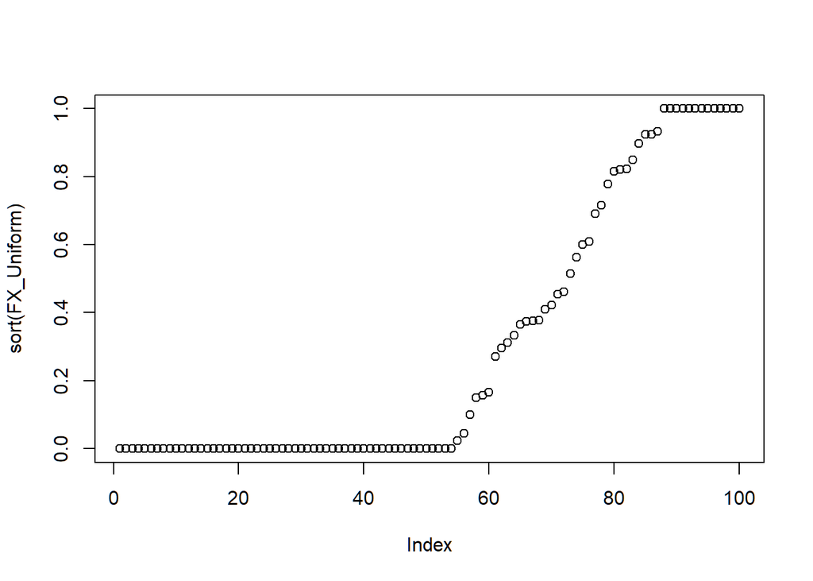

```r
FX_Uniform = punif(Random_Normal);
plot(sort(FX_Uniform))
```

### colMeans(X)求列平均

### qnorm 返回值是给定概率p后的下分位点，是pnorm的反函数

```r
n=100; p=0.3;
x=rbinom(100,1,0.3);
m=sum(x);
freq = m/n;
err = abs(freq-p);
print(err);
```

```
## [1] 0.01
```

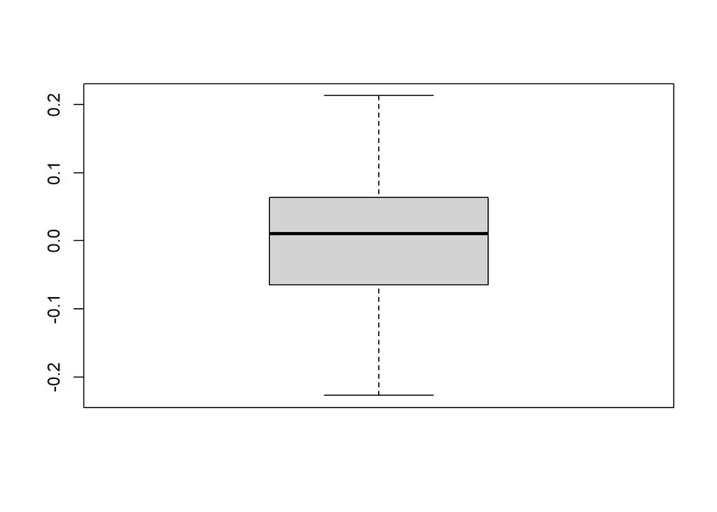

```r
X = matrix(rnorm(10000,1,1),100,100);
EX = colMeans(X);
err = EX-1;
boxplot(err);
```

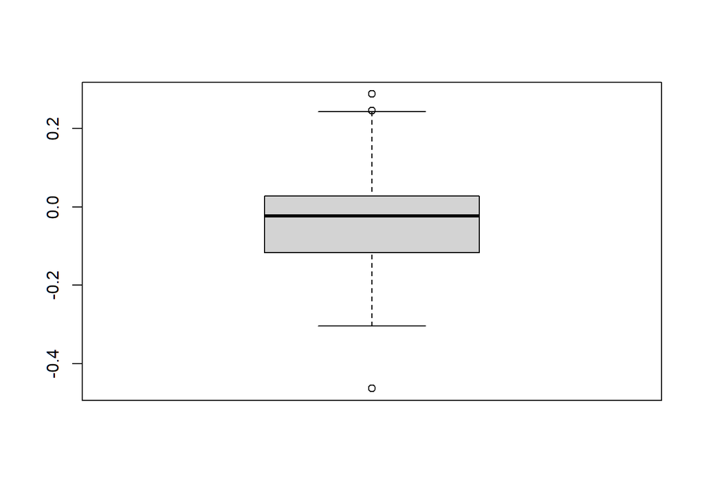

```r
X = matrix(rnorm(10000,1,1),100,100);
PX = apply(X,2,quantile,0.3);
Pu = qnorm(0.3,1,1);
err = PX - Pu;
boxplot(err)
```

```r
x1 = qnorm(0.05);   x2 = qnorm(0.95);
print(c(x1,x2));
```

```
## [1] -1.644854  1.644854
```

```r
y1 = qnorm(0.025);  y2 = qnorm(0.975);
print(c(y1,y2))
```

```
## [1] -1.959964  1.959964
```

### quantile计算百分位数

quantile(x,p) 计算公式：$(x_n-x_1)*p+x_1$

```r
x=1:11;
quantile(x,0.1)
```

```
## 10%
##   2
```

### rt(n,df)求T分布

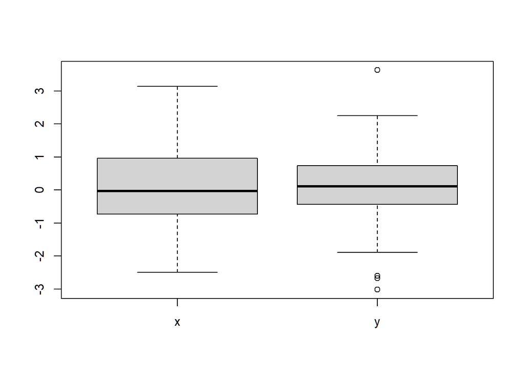

```r
x=rnorm(100);
y=rt(100,10);
Data=cbind(x,y);
boxplot(Data)
```

### median(x)中位数

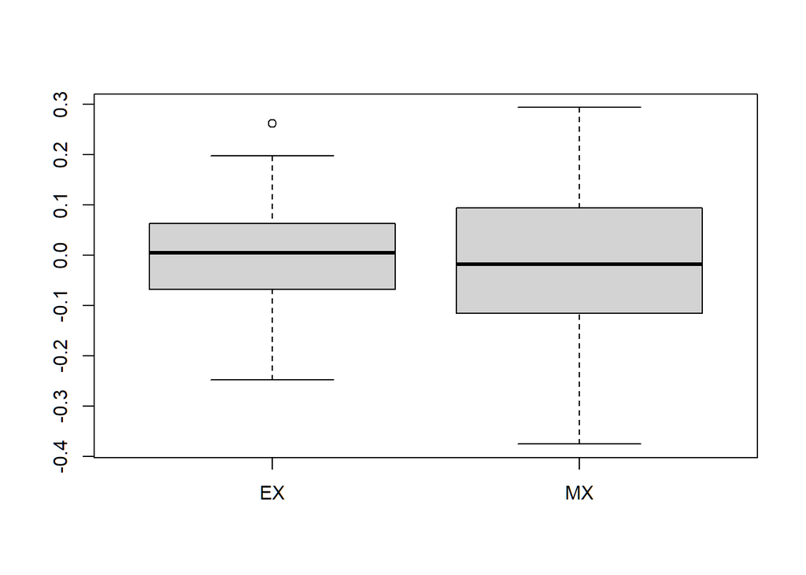

```r
X = matrix(rnorm(10000),100,100);
 EX = colMeans(X);
 EX = apply(X,2,mean);
 MX = apply(X,2,median);
 Data = cbind(EX,MX);
 boxplot(Data)
```

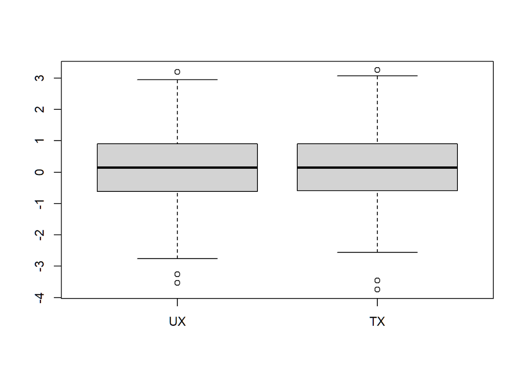

```r
N=200;n=30;
X = matrix(rnorm(N*n,1,sd=3),n,N);
EX = colMeans(X);
SX = apply(X,2,sd);
UX = (EX - 1)/(3/sqrt(n));
TX = (EX - 1)/(SX/sqrt(n));
Data = cbind(UX,TX);
boxplot(Data)
```

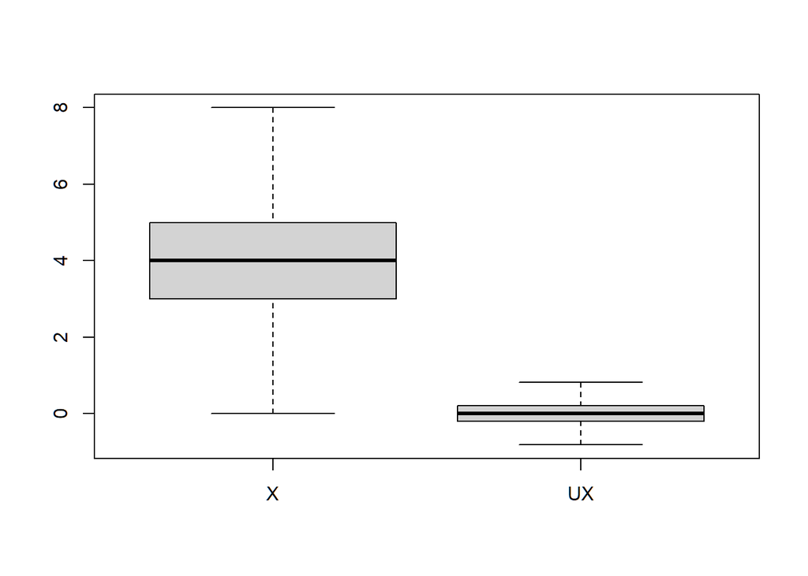

```r
X = rbinom(100,10,0.4);
Eu = 10 * 0.4;
Du = 100* 0.4 * (1-0.4);
UX = (X - Eu)/(sqrt(Du));
Data = cbind(X,UX);
boxplot(Data)
```

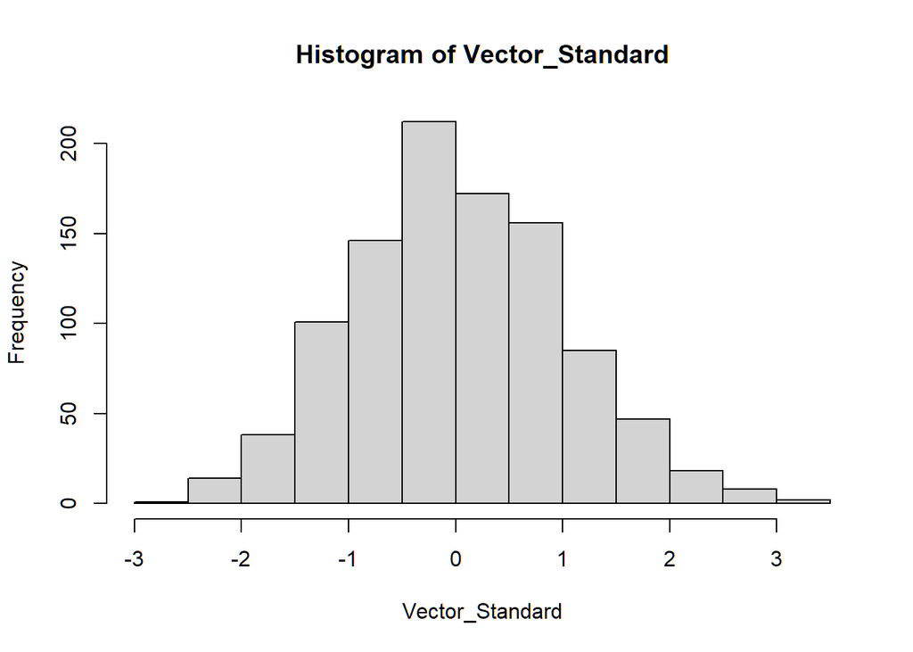

```r
Vector_Standard = as.numeric(vector(length = 1000));
for (k in 1:1000){
    Number_Sample = 500;
    Parameter_P = 0.8;
    SampleX =rbinom(Number_Sample,1,Parameter_P);
    Estimator_P = mean(SampleX);
    Delta = sqrt(Estimator_P*(1-Estimator_P)/Number_Sample);
    Value_Standard = (Estimator_P-Parameter_P)/Delta;
    Vector_Standard[k]= Value_Standard;}
hist(Vector_Standard);
```

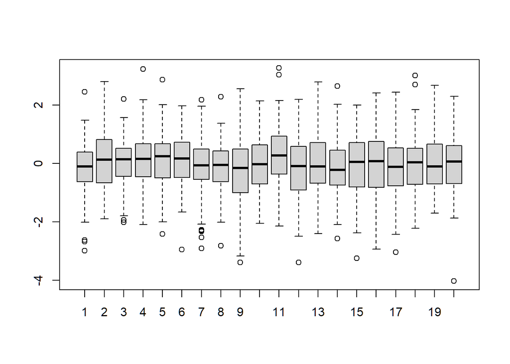

```r
X = matrix(rnorm(1000),100,10);
Y = matrix(nrow=100,ncol=10);
for(k in 1:10){Y[,k]=rnorm(100)};
boxplot(cbind(X,Y))
```

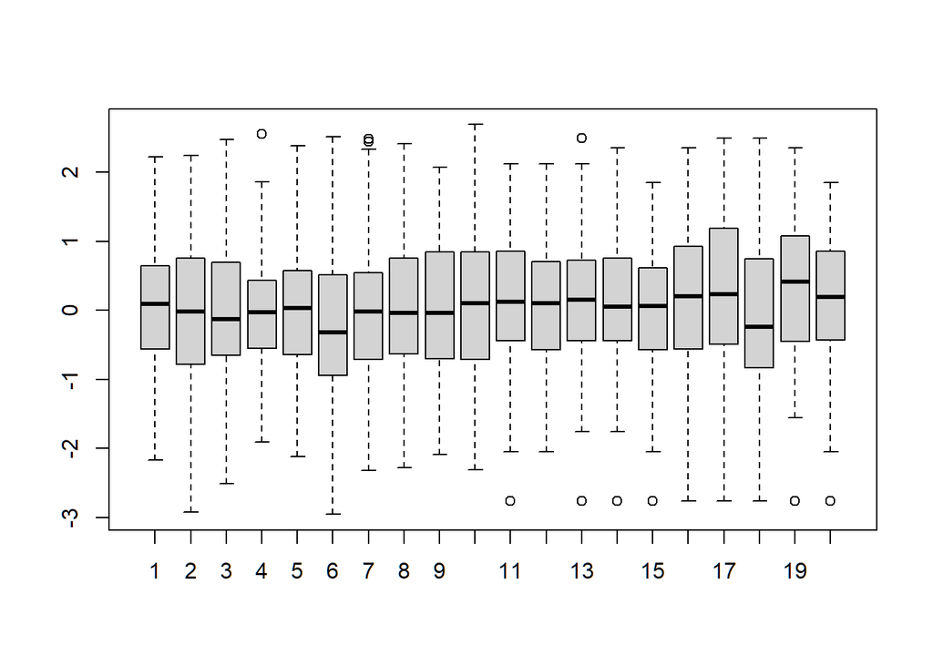

```r
X = matrix(rnorm(1000),100,10);
Z = rnorm(120);
Y = matrix(nrow=100,ncol=10);
for(k in 1:10){Y[,k]=sample(Z,100,replace=TRUE)};
boxplot(cbind(X,Y))
```

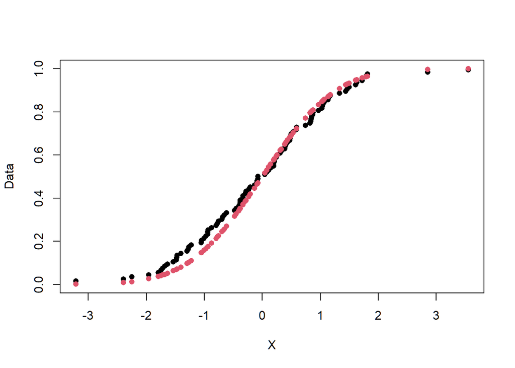

```r
X = sort(rnorm(100));
n = 1:100;
Y = (n+0.5)/(100+1);
Z = pnorm(X);
Data = cbind(Y,Z);
matplot(X,Data,pch = 16)
```

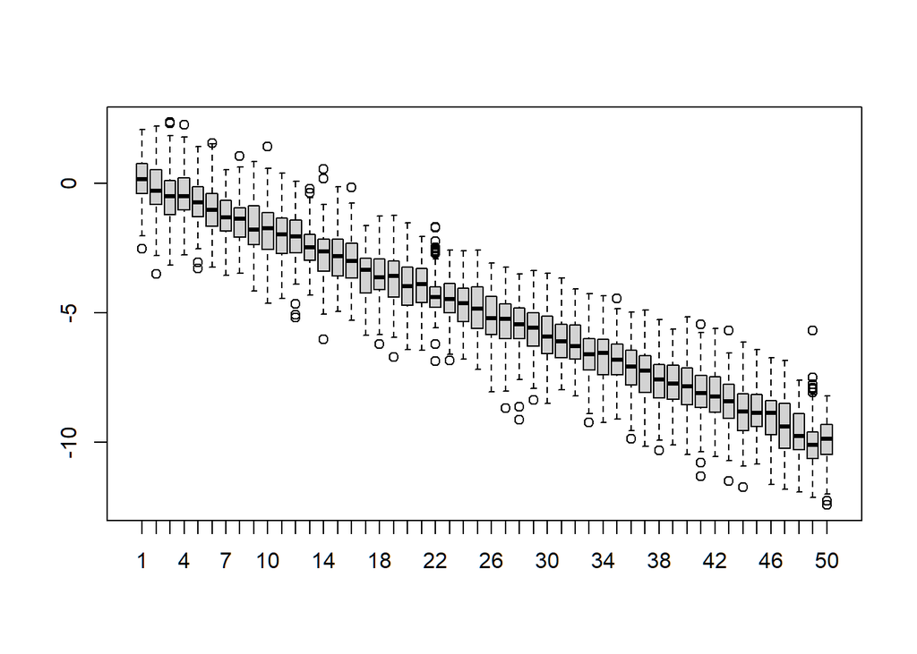

```r
u = seq(from=0,to=1,length.out=50);
T = matrix(nrow = 50,ncol=100)
for (k in 1:50){
  X = matrix(rnorm(10000),100,100);
  MX = colMeans(X);
  U =(MX - u[k])/(1/sqrt(100));
  T[k,] = U;}
boxplot(t(T))
```

### 一元线性回归

### lm_data = lm(y~x)

线性拟合x和y，把数据赋给lm_data

### summary(lm_data)

给出过程表

### abline(lm_data)

在图上加入拟合的直线（需要先画出散点图）

```r
 a = 0.8; b = 1.0;
 X = 1.2*runif(1000); e = 5*rnorm(1000); Y = a*X+b+e;
 S_Reg = lm(Y~X); summary(S_Reg);
```

```
##
## Call:
## lm(formula = Y ~ X)
##
## Residuals:
##      Min       1Q   Median       3Q      Max
## -13.5339  -3.4102  -0.0946   3.2400  14.6408
##
## Coefficients:
##             Estimate Std. Error t value Pr(>|t|)
## (Intercept)   1.2549     0.3140   3.996 6.91e-05 ***
## X             0.7068     0.4625   1.528    0.127
## ---
## Signif. codes:  0 '***' 0.001 '**' 0.01 '*' 0.05 '.' 0.1 ' ' 1
##
## Residual standard error: 4.986 on 998 degrees of freedom
## Multiple R-squared:  0.002335,   Adjusted R-squared:  0.001335
## F-statistic: 2.336 on 1 and 998 DF,  p-value: 0.1267
```

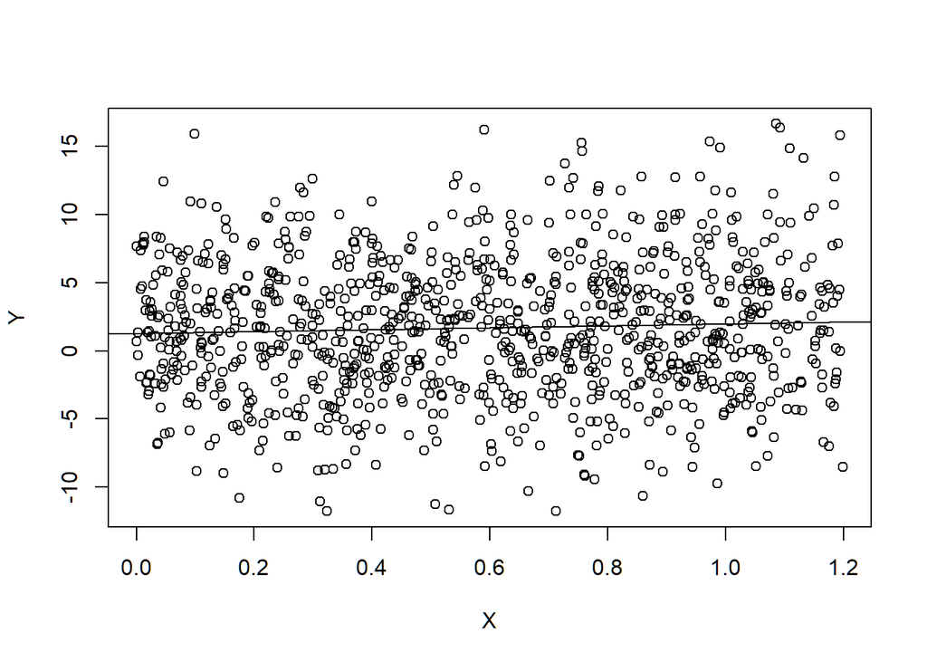

```r
 plot(X,Y); abline(S_Reg)
```

```r
a=c(1,2,3,4,5,6,7,8,9);
b=c(2,3,4,5,6,7.1,8,9.2,10);
l=lm(b~a);
summary(l);
```

```
##
## Call:
## lm(formula = b ~ a)
##
## Residuals:
##      Min       1Q   Median       3Q      Max
## -0.08000 -0.03333 -0.01000  0.01333  0.13167
##
## Coefficients:
##             Estimate Std. Error t value Pr(>|t|)
## (Intercept) 0.975000   0.048991    19.9 2.02e-07 ***
## a           1.011667   0.008706   116.2 9.22e-13 ***
## ---
## Signif. codes:  0 '***' 0.001 '**' 0.01 '*' 0.05 '.' 0.1 ' ' 1
##
## Residual standard error: 0.06744 on 7 degrees of freedom
## Multiple R-squared:  0.9995, Adjusted R-squared:  0.9994
## F-statistic: 1.35e+04 on 1 and 7 DF,  p-value: 9.216e-13
```

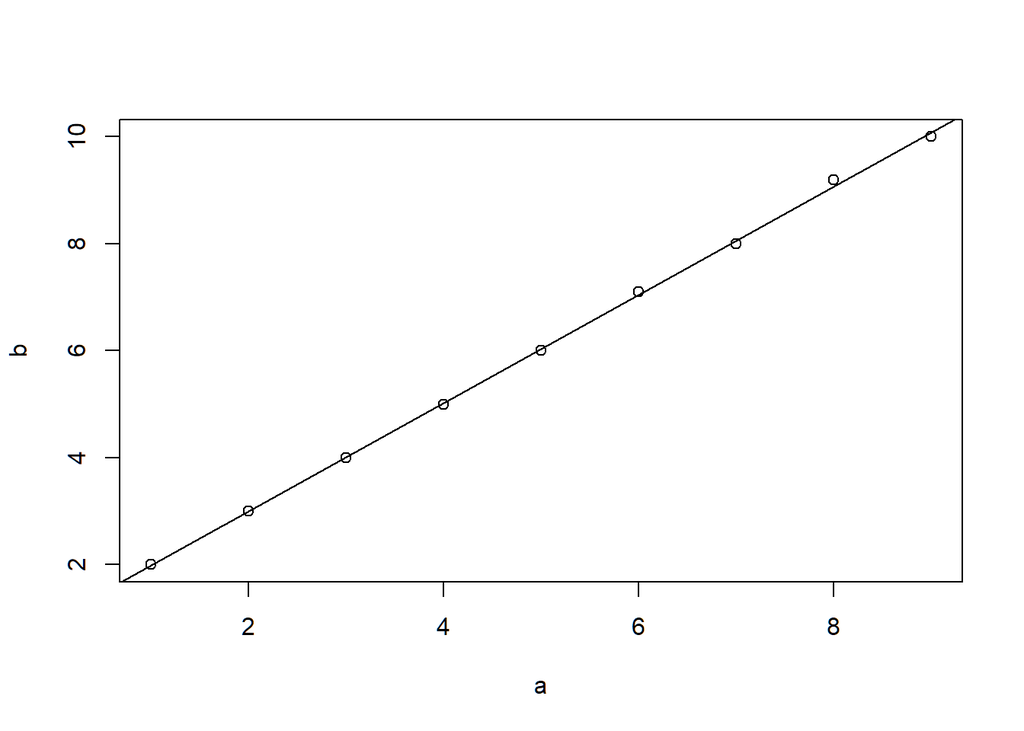

```r
plot(a,b);
abline(l)
```